# HDT4RegresionLineal

Ayleen Rubio 19003, Andrés Say 19705, Andreé Toledo 18439

18/3/2021

# Hoja de Trabajo No. 4: Modelos de regresión lineal

## Análisis Exploratorio

A continuación se mostrará un resumen de cada una de las variables y el tipo

```
##        Id           MSSubClass      MSZoning          LotFrontage
##  Min.   :   1.0   Min.   : 20.0   Length:1460        Min.   : 21.00
##  1st Qu.: 365.8   1st Qu.: 20.0   Class :character   1st Qu.: 59.00
##  Median : 730.5   Median : 50.0   Mode  :character   Median : 69.00
##  Mean   : 730.5   Mean   : 56.9                      Mean   : 70.05
##  3rd Qu.:1095.2   3rd Qu.: 70.0                      3rd Qu.: 80.00
##  Max.   :1460.0   Max.   :190.0                      Max.   :313.00
##                                                      NA's   :259
##     LotArea          Street             Alley             LotShape
##  Min.   :  1300   Length:1460        Length:1460        Length:1460
##  1st Qu.:  7554   Class :character   Class :character   Class :character
##  Median :  9478   Mode  :character   Mode  :character   Mode  :character
##  Mean   : 10517
##  3rd Qu.: 11602
##  Max.   :215245
##
##  LandContour         Utilities          LotConfig          LandSlope
##  Length:1460        Length:1460        Length:1460        Length:1460
##  Class :character   Class :character   Class :character   Class :character
##  Mode  :character   Mode  :character   Mode  :character   Mode  :character
##
##
##
##
##  Neighborhood        Condition1         Condition2          BldgType
##  Length:1460        Length:1460        Length:1460        Length:1460
##  Class :character   Class :character   Class :character   Class :character
##  Mode  :character   Mode  :character   Mode  :character   Mode  :character
##
##
##
##
##   HouseStyle         OverallQual      OverallCond      YearBuilt
##  Length:1460        Min.   : 1.000   Min.   :1.000   Min.   :1872
##  Class :character   1st Qu.: 5.000   1st Qu.:5.000   1st Qu.:1954
##  Mode  :character   Median : 6.000   Median :5.000   Median :1973
##                     Mean   : 6.099   Mean   :5.575   Mean   :1971
##                     3rd Qu.: 7.000   3rd Qu.:6.000   3rd Qu.:2000
##                     Max.   :10.000   Max.   :9.000   Max.   :2010
##
```

[output cut: 113 more lines]

```
##  Min.   : 1.000   Min.   :2006   Length:1460        Length:1460
##  1st Qu.: 5.000   1st Qu.:2007   Class :character   Class :character
##  Median : 6.000   Median :2008   Mode  :character   Mode  :character
##  Mean   : 6.322   Mean   :2008
##  3rd Qu.: 8.000   3rd Qu.:2009
##  Max.   :12.000   Max.   :2010
##
##    SalePrice
##  Min.   : 34900
##  1st Qu.:129975
##  Median :163000
##  Mean   :180921
##  3rd Qu.:214000
##  Max.   :755000
##
```

```
## 'data.frame':    1460 obs. of  81 variables:
##  $ Id           : int  1 2 3 4 5 6 7 8 9 10 ...
##  $ MSSubClass   : int  60 20 60 70 60 50 20 60 50 190 ...
##  $ MSZoning     : chr  "RL" "RL" "RL" "RL" ...
##  $ LotFrontage  : int  65 80 68 60 84 85 75 NA 51 50 ...
##  $ LotArea      : int  8450 9600 11250 9550 14260 14115 10084 10382 6120 7420 ...
##  $ Street       : chr  "Pave" "Pave" "Pave" "Pave" ...
##  $ Alley        : chr  NA NA NA NA ...
##  $ LotShape     : chr  "Reg" "Reg" "IR1" "IR1" ...
##  $ LandContour  : chr  "Lvl" "Lvl" "Lvl" "Lvl" ...
##  $ Utilities    : chr  "AllPub" "AllPub" "AllPub" "AllPub" ...
##  $ LotConfig    : chr  "Inside" "FR2" "Inside" "Corner" ...
##  $ LandSlope    : chr  "Gtl" "Gtl" "Gtl" "Gtl" ...
##  $ Neighborhood : chr  "CollgCr" "Veenker" "CollgCr" "Crawfor" ...
##  $ Condition1   : chr  "Norm" "Feedr" "Norm" "Norm" ...
```

[output cut: 67 more lines]

```
##
## character   integer
##        43        38
```

Con esto puede observarse que, del total de variables con las que cuenta nuestra base de datos, 43 son de tipo character y 38 son de tipo integer, siendo una de ellas el id por lo que no será utilizado en el futuro para formar grupos.

De estas variables se ha considerado que algunas de ellas valen la pena estudiarlas más a fondo para conocer las condiciones de los datos con los que se llevará a cabo el entrenamiento y las pruebas.

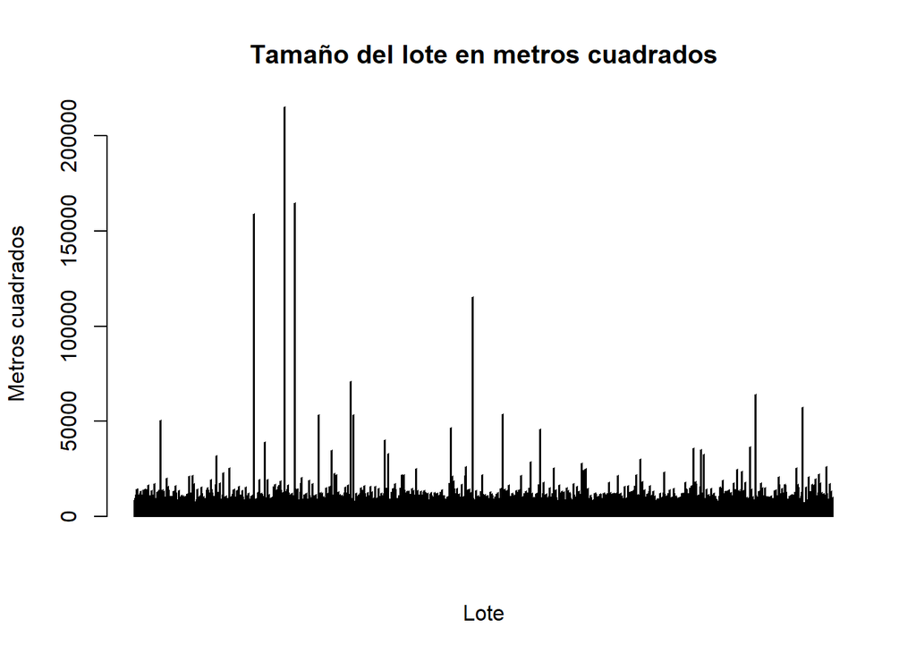

En este caso, puede observarse que la mayoría de casas se encuentra debajo de los 50,ooo metros cuadrados y que la casa que cuenta con mayor área de lote cuenta con más de 200,000 metros cuadrados.

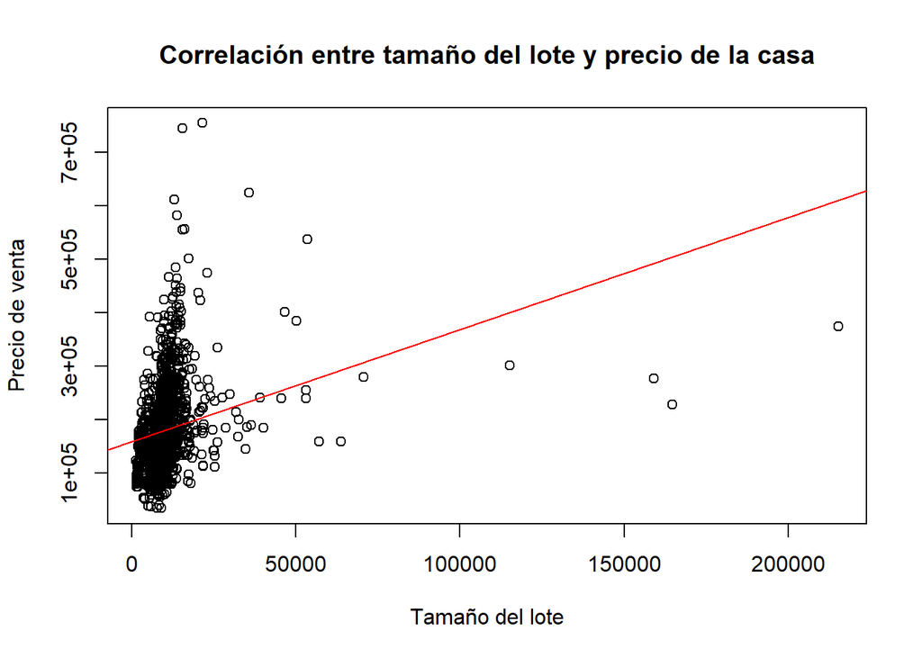

Puede observarse que no existe correlación entre el precio de la casa y el tamaño del lote, esto ya que la mayoría de valores se encuentran antes de los 50,000 metros cuadrados y el precio de venta cambia alrededor de los mismos tamaños de lote, además, las casas a mayor precio se encuentran entre los tamaño de lote menores.

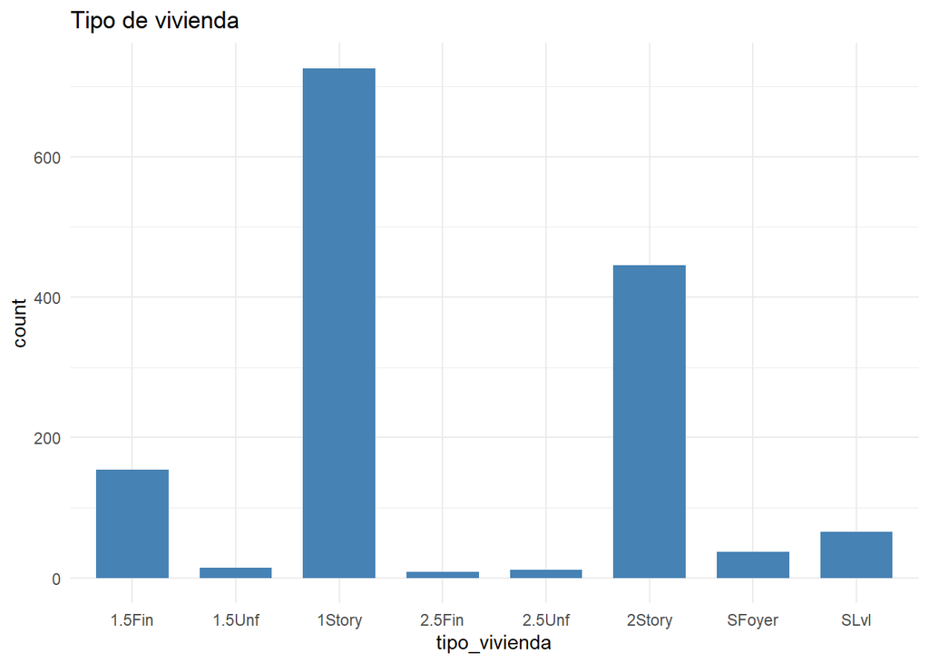

Puede observarse cómo es que el tipo de vivienda más común es el de un solo nivel, seguido por las casas de 2 niveles.

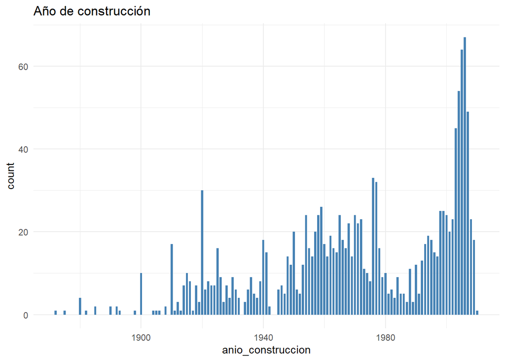

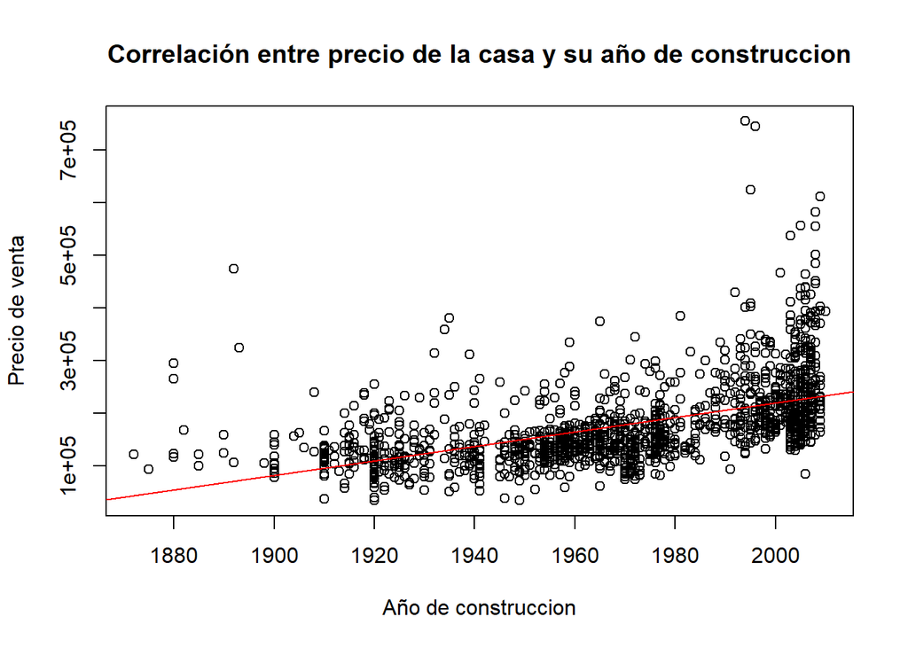

Como puede observarse, sí existe una correlación entre el año de construcción y el precio de la casa, ya que puede observarse cómo es que los valores de precio van aumentando a medida que los años van incrementando.

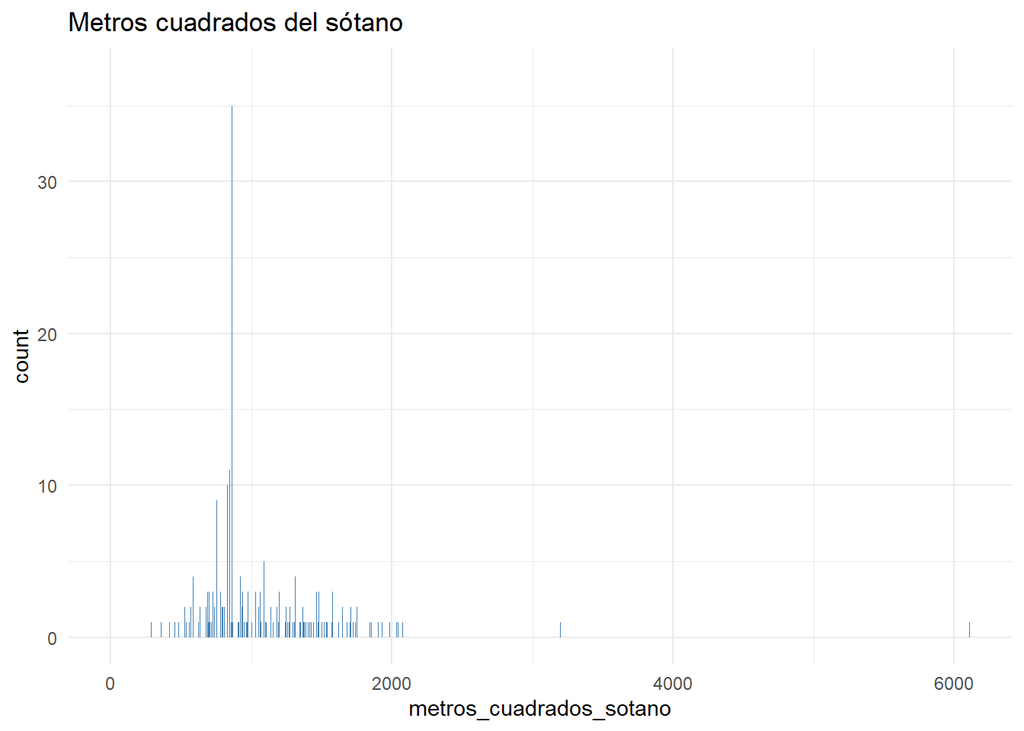

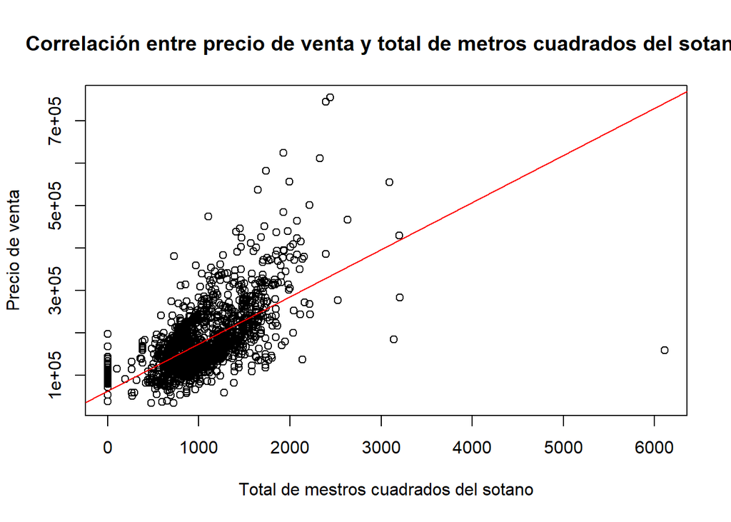

Según lo observado, a pesar que se cuente con lagunos puntos atipicos, sí existe una correlación entre el precio de venta y el total de metros cuadrados del area del sotano.

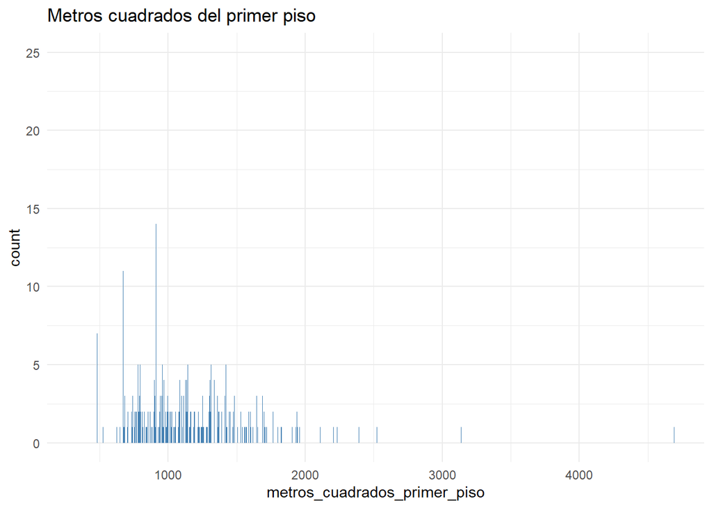

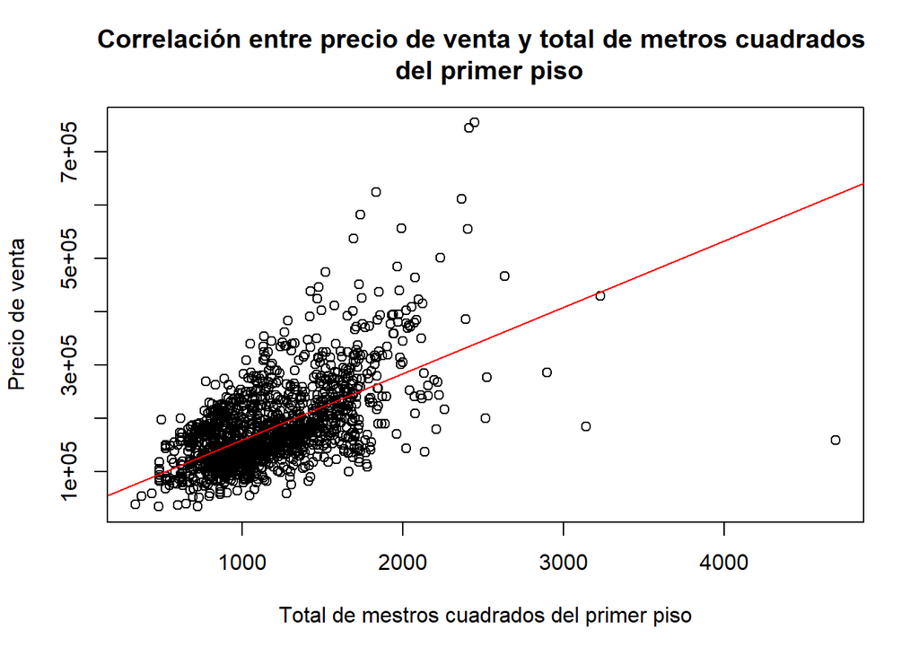

Puede observarse que sí existe correlación entre el total de metros cuadrados del primer piso y el precio de venta.

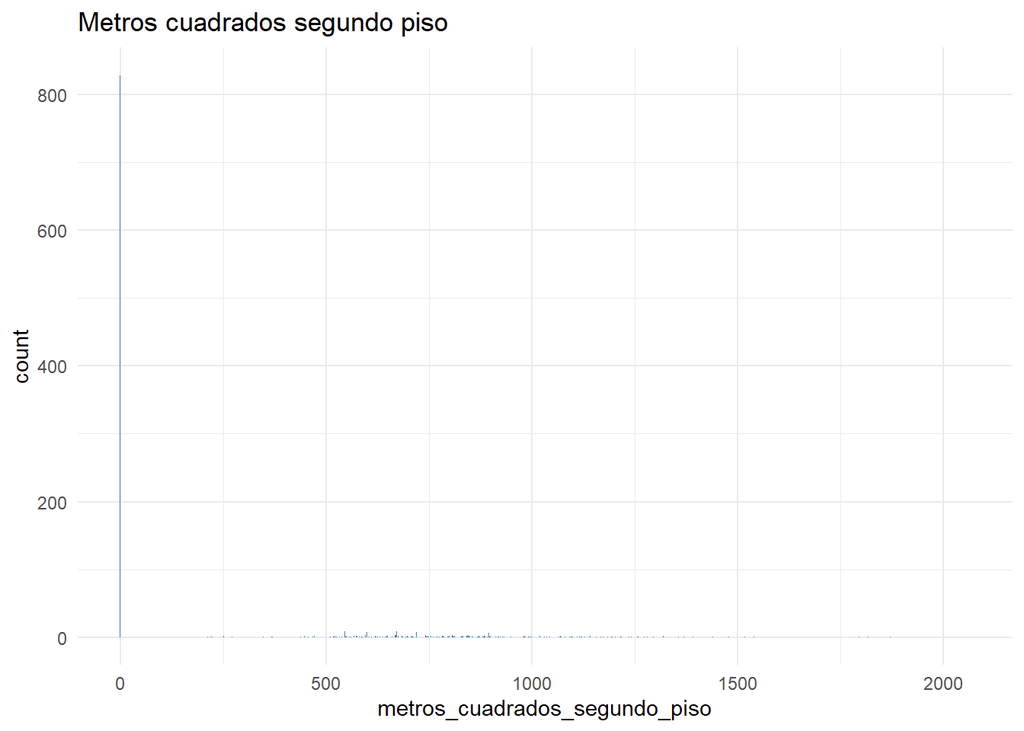

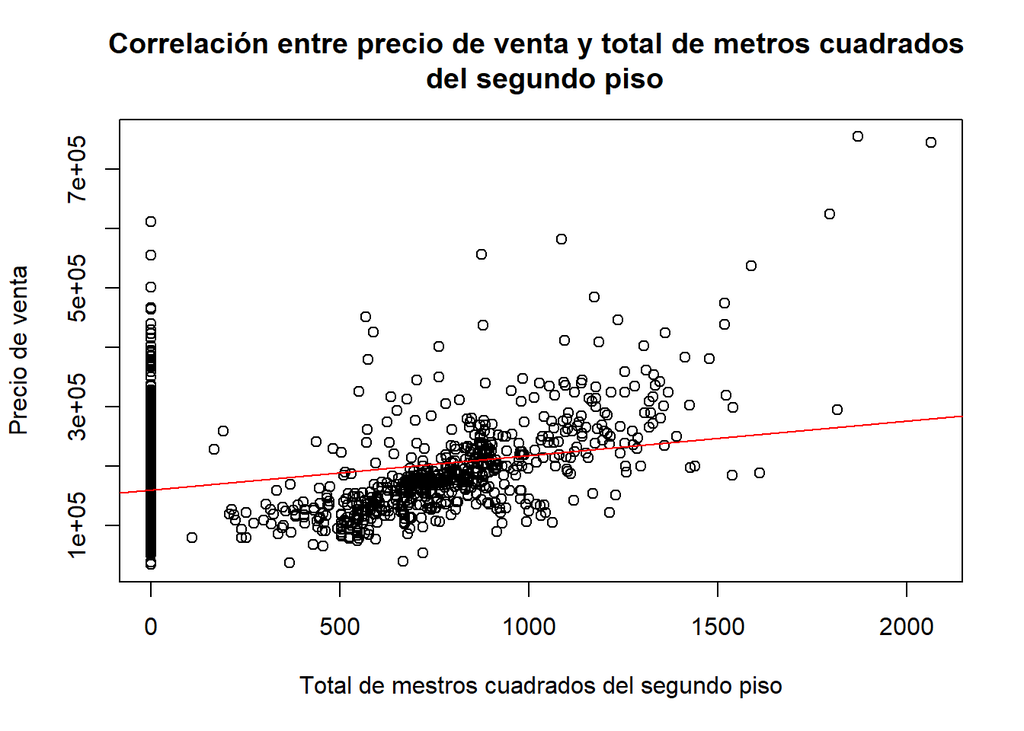

En este caso, los valores que cuentan con 0 metros cuadrados en el segundo piso hacen referencia a las casas que no cuentan con un segundo piso, por lo que, si no se toman en cuenta esos valores, sí existe correlación entre los metros cuadrados del segundo piso y el precio de venta de la casa.

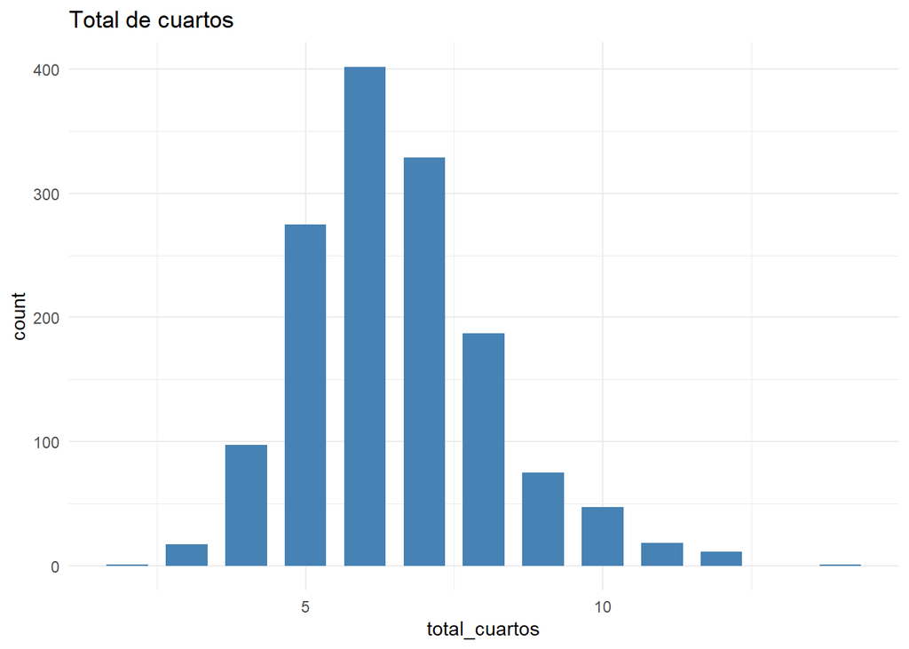

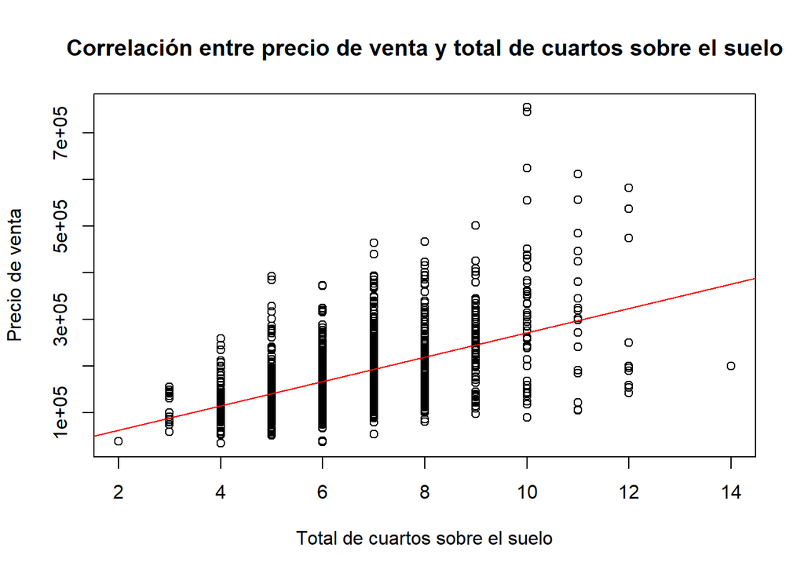

Puede observarse que en total de cuartos, sin tomar en cuenta los baños completos, la mayoría de casas cuenta con 6 cuartos. A su vez, puede observarse que este dato sí tiene correlación con el precio de venta, ya que a medida que va aumentando la cantidad de cuartos, va aumentando el precio de venta.

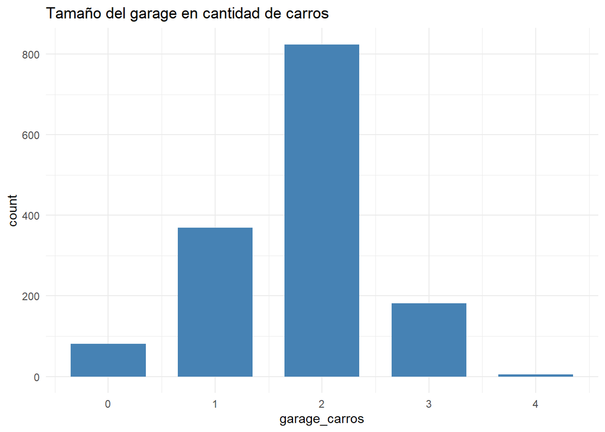

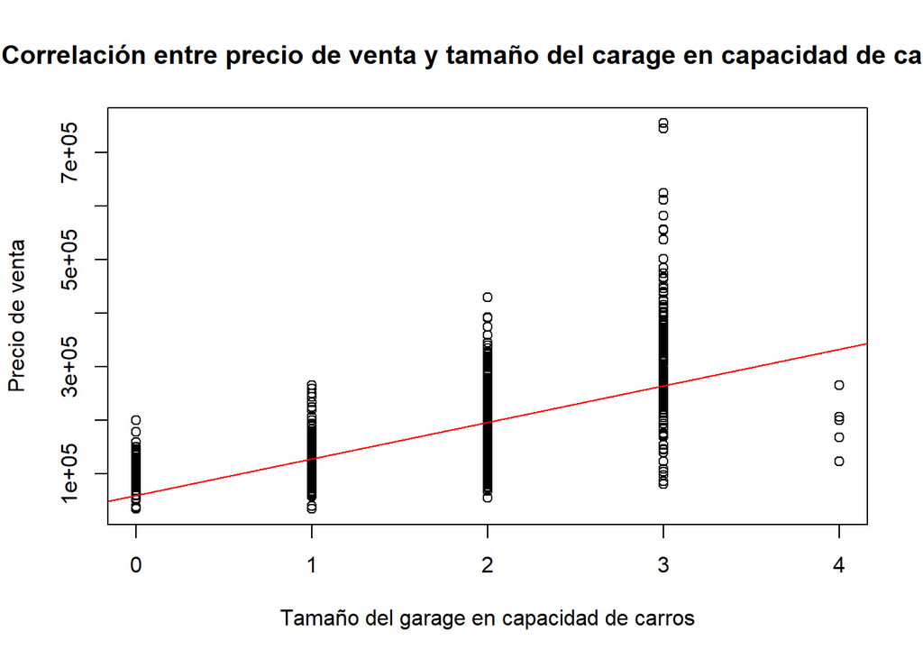

Puede observarse que la mayoría de casas tiene un garage con una capacidad de dos carros, al igual que existe una correlación entre este dato y el precio de venta, ya que a mayor cantidad de carros que entran en un garage, mayor precio de venta.

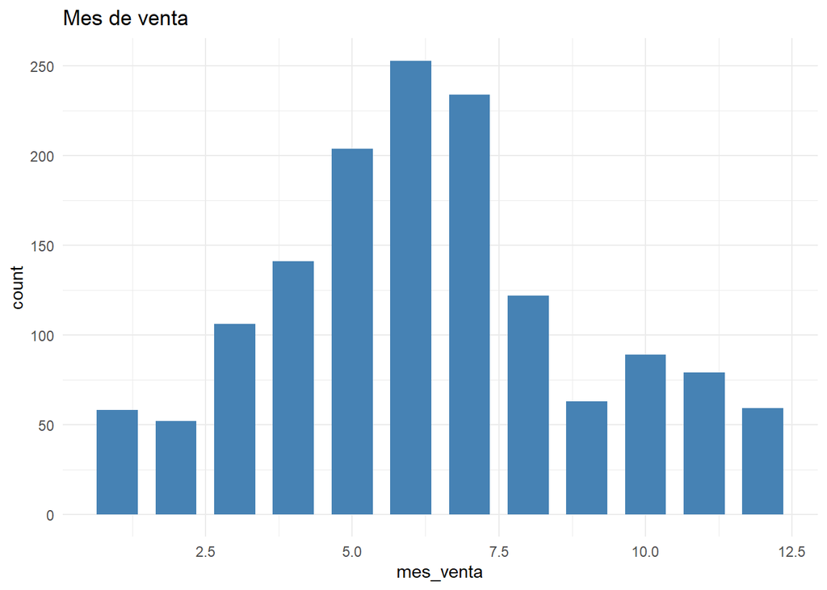

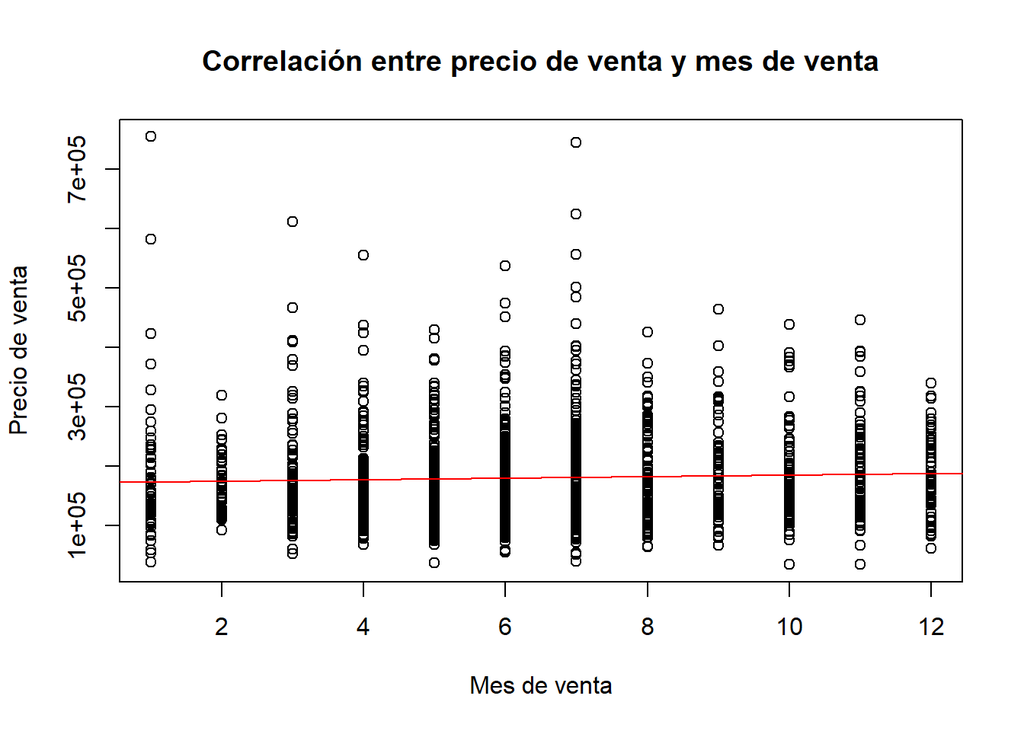

Puede observarse que han habido más ventas durante el mes de junio, sin embargo, no existe correlación entre el mes de venta y el precio de venta.

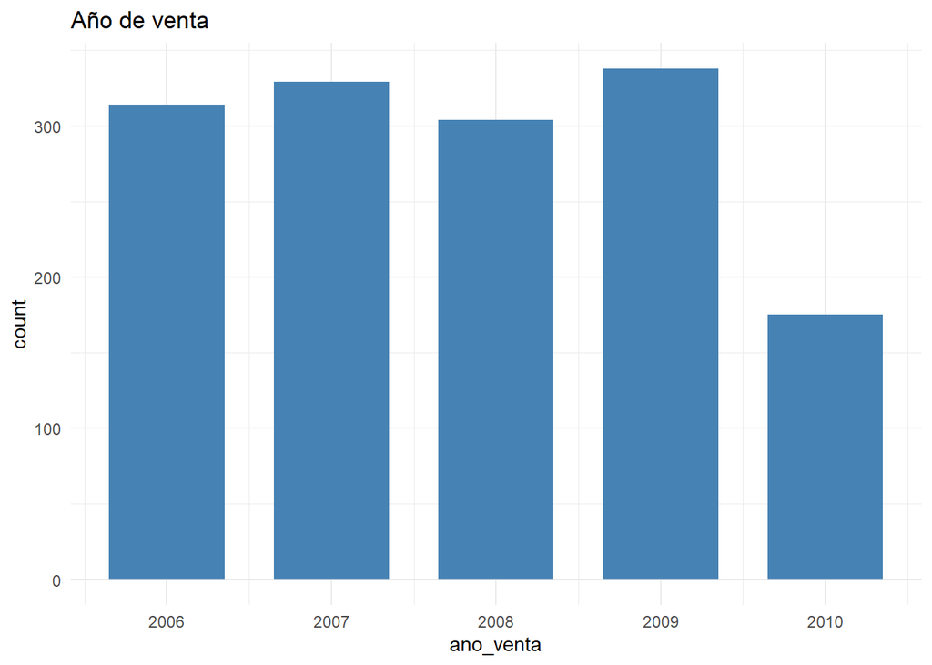

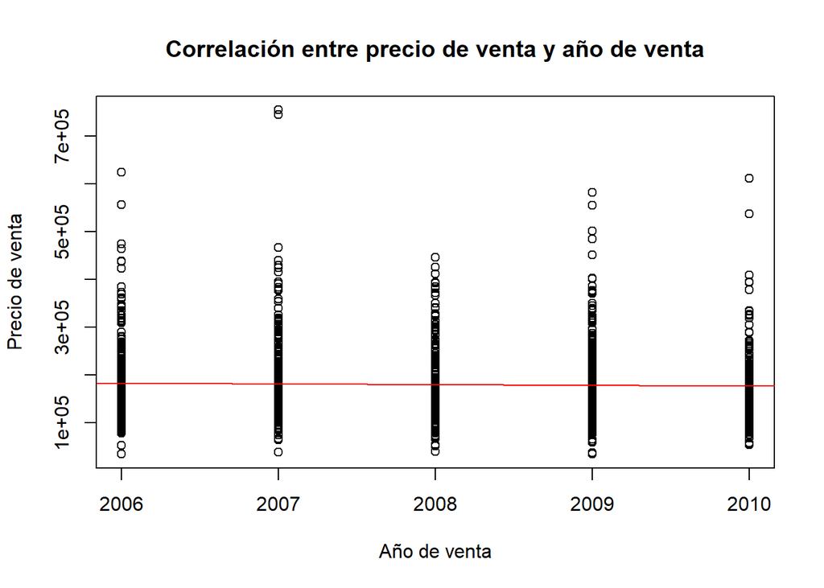

Puede observarse que han habido más ventas durante el 2009, sin embargo, no existe correlación entre el año de venta y el precio de venta.

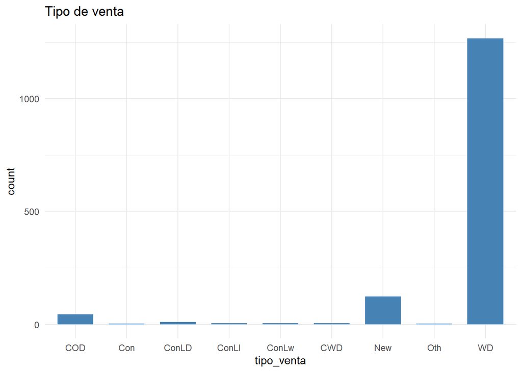

Puede observarse que el tipo de venta más común es el convencional con una escritura de garantía.

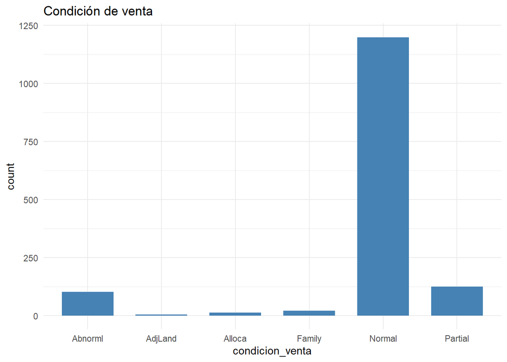

Por último, puede observarse que la condición de venta más común es una venta normal.

```
##
## Call:
## lm(formula = SalePrice ~ ., data = train)
##
## Residuals:
##     Min      1Q  Median      3Q     Max
## -409357  -13924   -1521   11097  356054
##
## Coefficients: (2 not defined because of singularities)
##                 Estimate Std. Error t value Pr(>|t|)
## (Intercept)   -4.064e+05  1.717e+06  -0.237 0.812984
## MSSubClass    -1.520e+02  3.248e+01  -4.680 3.26e-06 ***
## OverallQual    1.523e+04  1.494e+03  10.196  < 2e-16 ***
## OverallCond    4.302e+03  1.271e+03   3.386 0.000737 ***
## YearBuilt      3.472e+02  7.624e+01   4.553 5.94e-06 ***
## YearRemodAdd   1.128e+02  8.110e+01   1.391 0.164565
## BsmtFinSF1     1.868e+01  5.805e+00   3.218 0.001331 **
## BsmtFinSF2     8.863e+00  8.865e+00   1.000 0.317656
## BsmtUnfSF      7.719e+00  5.330e+00   1.448 0.147847
## TotalBsmtSF           NA         NA      NA       NA
## X1stFlrSF      4.513e+01  7.292e+00   6.188 8.89e-10 ***
## X2ndFlrSF      4.172e+01  6.006e+00   6.946 6.81e-12 ***
## LowQualFinSF   3.158e+01  2.310e+01   1.368 0.171753
## GrLivArea             NA         NA      NA       NA
## BsmtFullBath   6.811e+03  3.198e+03   2.130 0.033430 *
## BsmtHalfBath   9.361e+03  5.365e+03   1.745 0.081329 .
## FullBath       5.713e+03  3.515e+03   1.625 0.104417
## HalfBath      -1.497e+02  3.257e+03  -0.046 0.963340
## BedroomAbvGr  -9.937e+03  2.087e+03  -4.762 2.20e-06 ***
## KitchenAbvGr  -1.536e+04  6.372e+03  -2.410 0.016134 *
## TotRmsAbvGrd   5.698e+03  1.528e+03   3.730 0.000203 ***
## Fireplaces     4.313e+03  2.144e+03   2.012 0.044530 *
## GarageCars     1.217e+04  3.478e+03   3.498 0.000490 ***
## GarageArea    -1.132e+01  1.166e+01  -0.971 0.331910
## WoodDeckSF     2.184e+01  9.935e+00   2.198 0.028178 *
## OpenPorchSF   -2.412e+01  1.853e+01  -1.302 0.193369
## EnclosedPorch  1.174e+01  2.133e+01   0.550 0.582223
## X3SsnPorch     3.492e+01  3.496e+01   0.999 0.318074
## ScreenPorch    4.727e+01  2.126e+01   2.224 0.026395 *
## PoolArea      -6.411e-01  3.308e+01  -0.019 0.984540
## MiscVal        2.427e-02  2.144e+00   0.011 0.990970
## MoSold        -2.243e+02  4.264e+02  -0.526 0.599008
## YrSold        -3.044e+02  8.539e+02  -0.356 0.721578
## y              3.591e+04  3.874e+03   9.270  < 2e-16 ***
## ---
## Signif. codes:  0 '***' 0.001 '**' 0.01 '*' 0.05 '.' 0.1 ' ' 1
##
## Residual standard error: 35520 on 989 degrees of freedom
## Multiple R-squared:  0.8068, Adjusted R-squared:  0.8007
## F-statistic: 133.2 on 31 and 989 DF,  p-value: < 2.2e-16
```

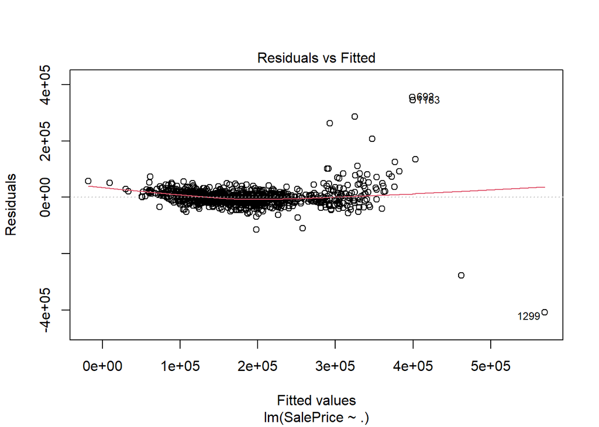

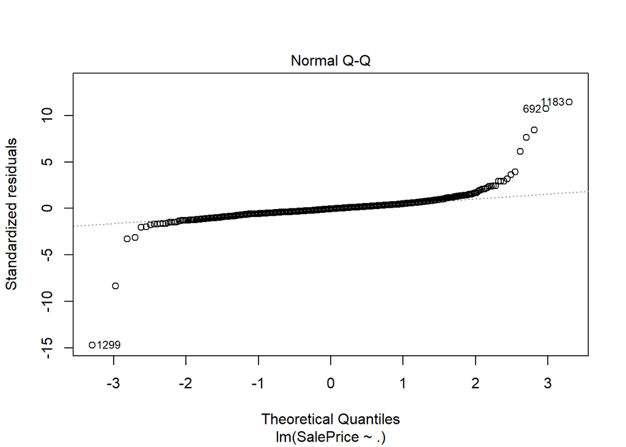

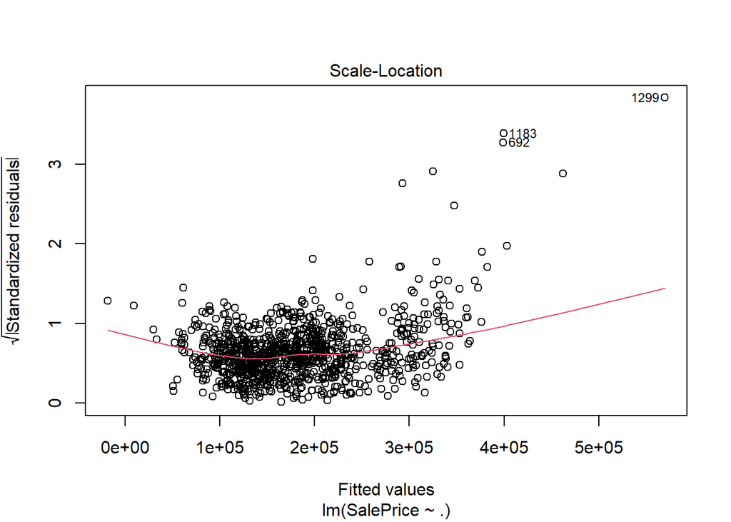

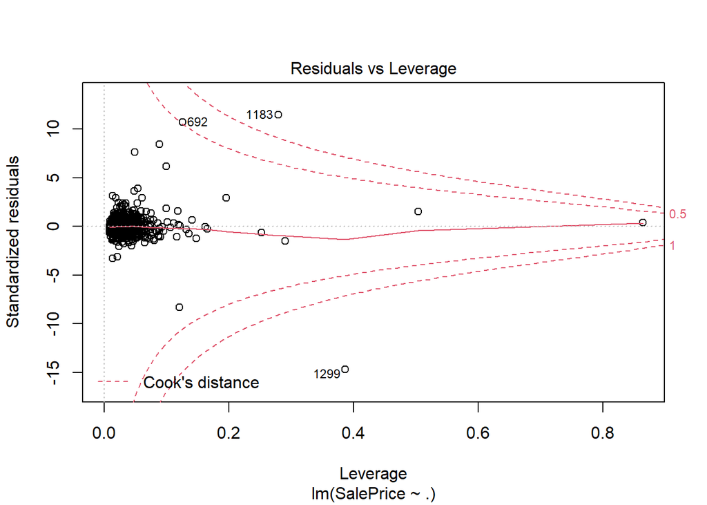

Puede observarse que el valor R cuadrado es 0.8068, por lo que se puede decir que el modelo predice un 81% de los precios de las casas, sin embargo, se evaluará la multicolinealidad entre variables para poder mejorar este porcentaje.

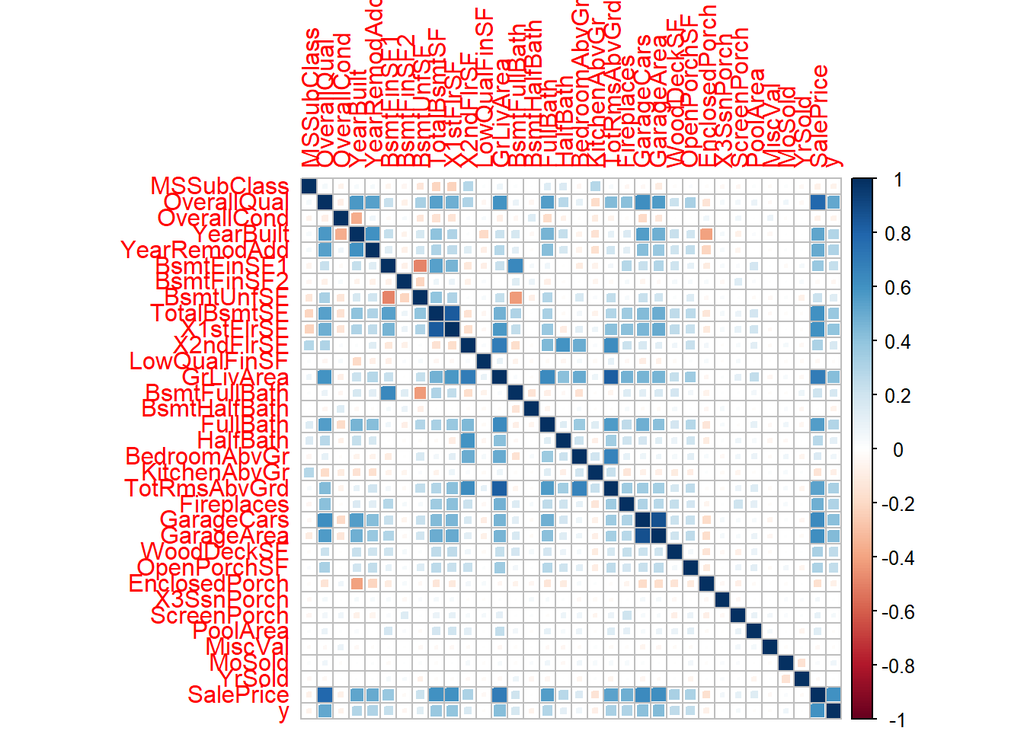

```
##                  MSSubClass OverallQual  OverallCond     YearBuilt
## MSSubClass     1.0000000000  0.04629126 -0.067476560  0.0398773289
## OverallQual    0.0462912621  1.00000000 -0.089027646  0.5767934515
## OverallCond   -0.0674765603 -0.08902765  1.000000000 -0.3658445415
## YearBuilt      0.0398773289  0.57679345 -0.365844542  1.0000000000
## YearRemodAdd   0.0424477768  0.54607776  0.062357494  0.6057940022
## BsmtFinSF1    -0.0593706990  0.22990487 -0.028682752  0.2373339267
## BsmtFinSF2    -0.0497519687 -0.07894730  0.031899102 -0.0625489096
## BsmtUnfSF     -0.1307018391  0.32698757 -0.136484102  0.1716289181
## TotalBsmtSF   -0.2120230406  0.54194451 -0.155172651  0.4005297507
## X1stFlrSF     -0.2272675865  0.48069158 -0.148960572  0.3017714444
## X2ndFlrSF      0.2861140370  0.30291059  0.020799948  0.0130806137
## LowQualFinSF   0.0192558131 -0.04723801  0.033745903 -0.1979251465
## GrLivArea      0.0722100549  0.59282773 -0.087647452  0.2104809335
## BsmtFullBath   0.0183173031  0.08170664 -0.043225910  0.1770528455
## BsmtHalfBath   0.0009067754 -0.04338429  0.147139146 -0.0362570567
## FullBath       0.1443444303  0.55998654 -0.183831368  0.4672811773
## HalfBath       0.1518478974  0.27414782 -0.071278409  0.2389533551
## BedroomAbvGr  -0.0460894957  0.10229135 -0.012131540 -0.0684085168
## KitchenAbvGr   0.2803488891 -0.18646743 -0.107685206 -0.1551014247
## TotRmsAbvGrd   0.0354552424  0.43706773 -0.062971983  0.1030249926
## Fireplaces    -0.0419753967  0.41207658 -0.018086940  0.1593715339
## GarageCars    -0.0369284834  0.61799565 -0.190105276  0.5521239540
## GarageArea    -0.1043155244  0.56322354 -0.135275805  0.4801629137
## WoodDeckSF    -0.0198424867  0.21903402 -0.006824670  0.2288168675
## OpenPorchSF    0.0233553699  0.32360684 -0.009428137  0.1924332131
## EnclosedPorch -0.0189306650 -0.14574211  0.067142051 -0.4019601483
## X3SsnPorch    -0.0349346729  0.04034655 -0.003221482  0.0428912614
## ScreenPorch   -0.0407043484  0.05877200  0.067236953 -0.0752561892
## PoolArea       0.0155153800  0.08571684  0.005806682  0.0266763023
## MiscVal       -0.0204440604 -0.03199433  0.082254456 -0.0398207865
## MoSold         0.0171131526  0.06701507 -0.010986721  0.0017095329
## YrSold        -0.0351423290 -0.03427464  0.003446218  0.0006485085
## SalePrice     -0.0743317293  0.78389196 -0.072652406  0.5229017715
## y             -0.0629894072  0.51348339 -0.063415099  0.2913298925
##                YearRemodAdd   BsmtFinSF1   BsmtFinSF2    BsmtUnfSF  TotalBsmtSF
## MSSubClass     0.0424477768 -0.059370699 -0.049751969 -0.130701839 -0.212023041
## OverallQual    0.5460777561  0.229904872 -0.078947302  0.326987573  0.541944509
## OverallCond    0.0623574935 -0.028682752  0.031899102 -0.136484102 -0.155172651
## YearBuilt      0.6057940022  0.237333927 -0.062548910  0.171628918  0.400529751
```

[output cut: 225 more lines]

```
## TotRmsAbvGrd   0.536770870  0.327181355
## Fireplaces     0.482291344  0.300387623
## GarageCars     0.637244403  0.410125749
## GarageArea     0.612457468  0.432487083
## WoodDeckSF     0.323090474  0.253762217
## OpenPorchSF    0.316092326  0.242202618
## EnclosedPorch -0.161321206 -0.078586868
## X3SsnPorch     0.051281458  0.006102102
## ScreenPorch    0.101435262  0.045701445
## PoolArea       0.138565425 -0.010311365
## MiscVal       -0.030661260 -0.015011578
## MoSold         0.029094998  0.061391405
## YrSold        -0.021729516 -0.004815830
## SalePrice      1.000000000  0.602629388
## y              0.602629388  1.000000000
```

Se planteó un nuevo modelo

```
##
## Call:
## lm(formula = train2$SalePrice ~ ., data = train2)
##
## Residuals:
##     Min      1Q  Median      3Q     Max
## -103161  -15420    -915   13525  286426
##
## Coefficients: (1 not defined because of singularities)
##                 Estimate Std. Error t value Pr(>|t|)
## (Intercept)   -7.849e+05  1.523e+06  -0.515 0.606405
## MSSubClass    -3.462e+01  2.672e+01  -1.296 0.195440
## OverallCond    1.873e+03  1.003e+03   1.867 0.062149 .
## YearRemodAdd   5.437e+02  6.277e+01   8.661  < 2e-16 ***
## BsmtFinSF1     6.517e+01  4.299e+00  15.159  < 2e-16 ***
## BsmtFinSF2     3.902e+01  7.087e+00   5.506 4.67e-08 ***
## BsmtUnfSF      4.243e+01  3.586e+00  11.832  < 2e-16 ***
## TotalBsmtSF           NA         NA      NA       NA
## LowQualFinSF  -2.584e+01  2.162e+01  -1.195 0.232392
## GrLivArea      4.696e+01  5.053e+00   9.294  < 2e-16 ***
## BsmtFullBath  -7.470e+02  2.893e+03  -0.258 0.796267
## BsmtHalfBath  -7.325e+03  4.718e+03  -1.553 0.120820
## FullBath       1.070e+04  2.871e+03   3.726 0.000205 ***
## HalfBath       6.982e+03  2.564e+03   2.723 0.006587 **
## KitchenAbvGr  -3.305e+04  5.198e+03  -6.358 3.11e-10 ***
## TotRmsAbvGrd   1.298e+03  1.225e+03   1.060 0.289312
## Fireplaces     6.051e+03  1.864e+03   3.247 0.001206 **
## GarageCars     1.298e+04  3.108e+03   4.178 3.21e-05 ***
## GarageArea     9.736e+00  1.049e+01   0.928 0.353407
## WoodDeckSF     9.080e+00  8.832e+00   1.028 0.304161
## OpenPorchSF    1.945e+01  1.695e+01   1.148 0.251358
## EnclosedPorch -3.493e+01  1.738e+01  -2.009 0.044766 *
## X3SsnPorch     2.507e+01  3.150e+01   0.796 0.426274
## ScreenPorch    1.676e+01  1.931e+01   0.868 0.385785
## PoolArea       1.024e-01  2.899e+01   0.004 0.997182
## MiscVal        7.852e-01  1.906e+00   0.412 0.680429
## MoSold        -2.146e+02  3.743e+02  -0.573 0.566618
## YrSold        -1.799e+02  7.588e+02  -0.237 0.812670
## y              4.207e+04  3.464e+03  12.148  < 2e-16 ***
## ---
## Signif. codes:  0 '***' 0.001 '**' 0.01 '*' 0.05 '.' 0.1 ' ' 1
##
## Residual standard error: 31410 on 989 degrees of freedom
## Multiple R-squared:  0.8402, Adjusted R-squared:  0.8359
## F-statistic: 192.7 on 27 and 989 DF,  p-value: < 2.2e-16
```

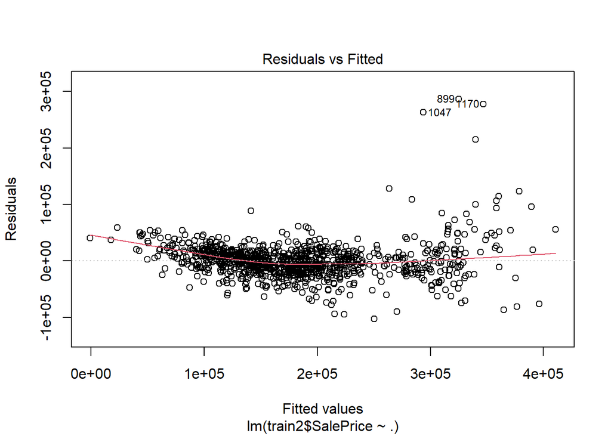

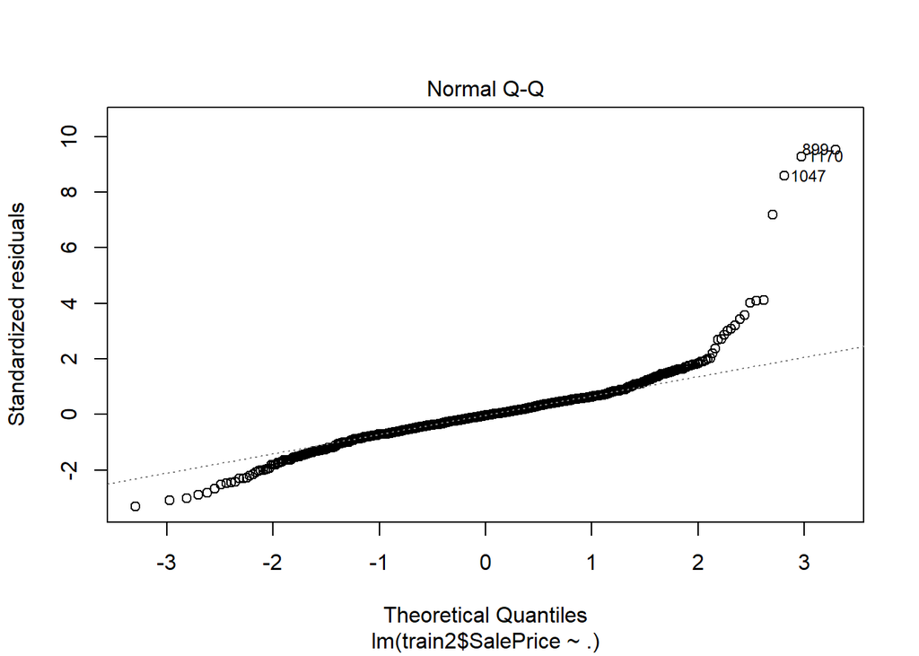

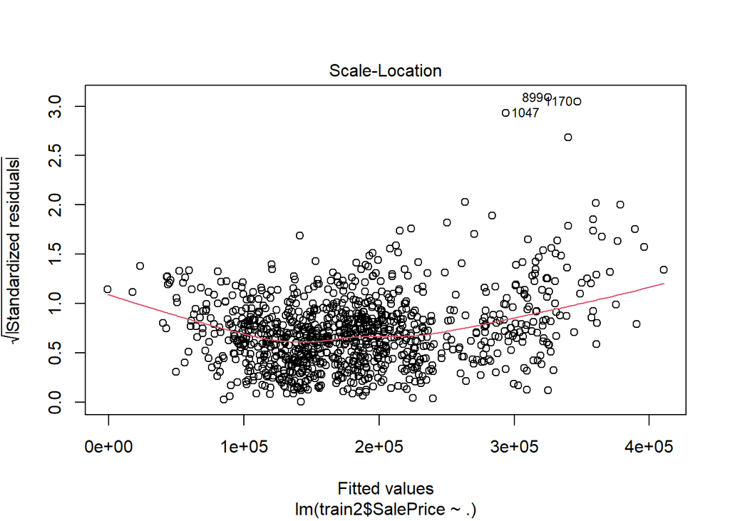

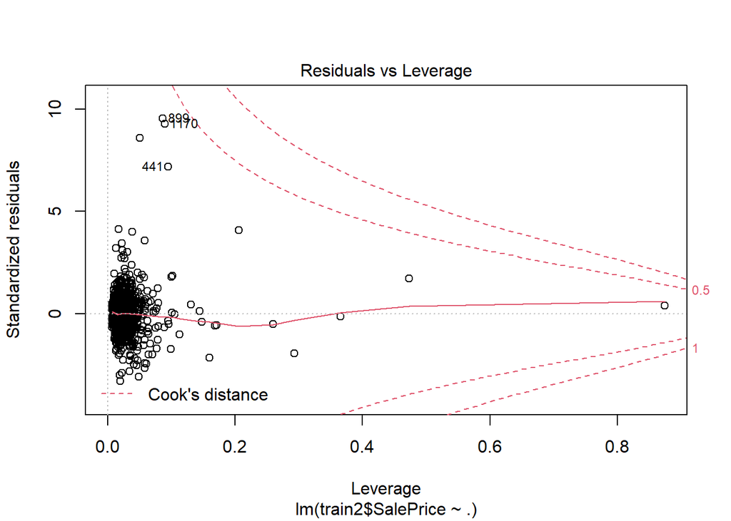

```
## [1] 50.30789
```

eliminando multicolinealidad el valor de R cuadrado aumentó a 0.8402, además se noto que la media era un valor grande, esto se debe probablemente a la gran cantidad de datos atipicos que se evidencian en el gráfico de residuos, por lo tanto, se eliminó algunos de los puntos atípicos para disminuir la media a 50.3

```
##
## Call:
## lm(formula = YearBuilt ~ SalePrice, data = datosCasas)
##
## Residuals:
##      Min       1Q   Median       3Q      Max
## -137.730  -12.378    2.988   19.349   53.901
##
## Coefficients:
##              Estimate Std. Error t value Pr(>|t|)
## (Intercept) 1.935e+03  1.677e+00 1154.09   <2e-16 ***
## SalePrice   1.988e-04  8.487e-06   23.42   <2e-16 ***
## ---
## Signif. codes:  0 '***' 0.001 '**' 0.01 '*' 0.05 '.' 0.1 ' ' 1
##
## Residual standard error: 25.75 on 1458 degrees of freedom
## Multiple R-squared:  0.2734, Adjusted R-squared:  0.2729
## F-statistic: 548.7 on 1 and 1458 DF,  p-value: < 2.2e-16
```

```
## [1] 0.9079814
```